# Analysis of Traumabase dataset

Wei Jiang

6/25/2018

This file contains the code for the exploration of Traumabase dataset, application of SAEM on Traumabase to explain the risk of hemorragic shock of severely traumatised patients.

```r
library(ggplot2)
library(tidyr)
library(knitr)
library(MASS)
library(mvtnorm)
library(mice)
library(ROCR)
library(misaem)
library(naniar)
library(missMDA)
library(FactoMineR)
```

Here we first :

1. load the datasets;
2. select the prehospital variables;
3. correct false calculation of BMI; Patients were excluded if
4. they had suffered from penetrating trauma (where an object such as a weapon or burns have pierced the skin and entered body tissue, creating an open wound)
5. they had been in pre-hospital traumatic cardiac arrest, or when no pre-hospital data was available.

```r
traumdata <- read.csv(file=\trauma.csv\,sep=';',dec=',',header = TRUE,na.strings = c(\\,\NR\,\IMP\,\NA\,\NF\),encoding = \UTF-8\)
SAMU <- traumdata[ ,c(10:14,225:228,234,33:35,15,18,229:233,244,19:30,41:42,49:54,48,58,61,44,46:47,55:57,60,62, 38)]

SAMU$BMI[3302]=SAMU$Poids[3302]/(SAMU$Taille[3302]^2)

SAMU=SAMU[-which(SAMU$ACR.1==1),]
Choc.hemorragique= traumdata$Choc.hemorragique
Choc.hemorragique = Choc.hemorragique[-which(traumdata$ACR.1==1)]

Choc.hemorragique = Choc.hemorragique[-which(SAMU$Mecanisme==\Arme blanche\ | SAMU$Mecanisme==\Arme à feu\)]
SAMU=SAMU[-which(SAMU$Mecanisme==\Arme blanche\ | SAMU$Mecanisme==\Arme à feu\),]

SAMU_CONT = SAMU[,c(1,3:5,34:41,43:44,48:50)]
indx <- sapply(SAMU_CONT, is.factor)
SAMU_CONT[indx] <- lapply(SAMU_CONT[indx], function(x) as.numeric(as.character(x)))
SAMU_CONT$SD.min=SAMU_CONT$PAS.min-SAMU_CONT$PAD.min
SAMU_CONT$SD.SMUR=SAMU_CONT$PAS.SMUR-SAMU_CONT$PAD.SMUR
SAMU_NEW = SAMU_CONT[,-c(7:8,10:11,15)]
```

Plot the percentage of missingness

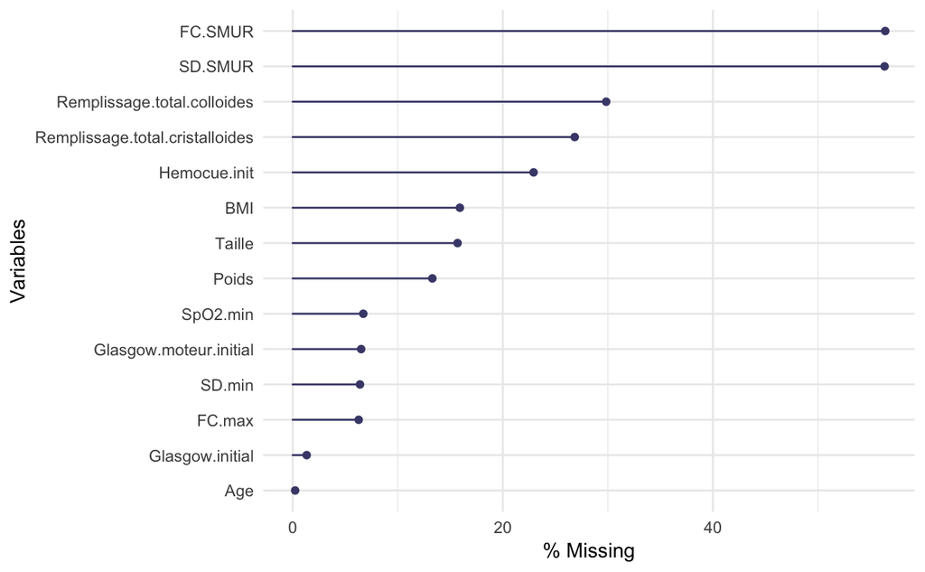

```r
gg_miss_var(SAMU_NEW,show_pct = TRUE)+ ylab('% Missing')
```

PCA

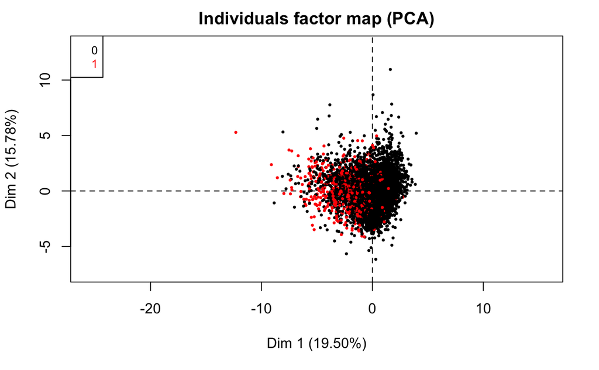

```r
res.comp = imputePCA(SAMU_NEW) #iterative PCA
imp = cbind.data.frame(as.factor(Choc.hemorragique),res.comp$completeObs)
#perform the PCA on the completed data set using the PCA function of the FactoMineR package
res.pca = PCA(imp,quali.sup = 1,graph = FALSE)
plot(res.pca,choix='ind',hab=1, lab ='quali',cex=0.5)
```

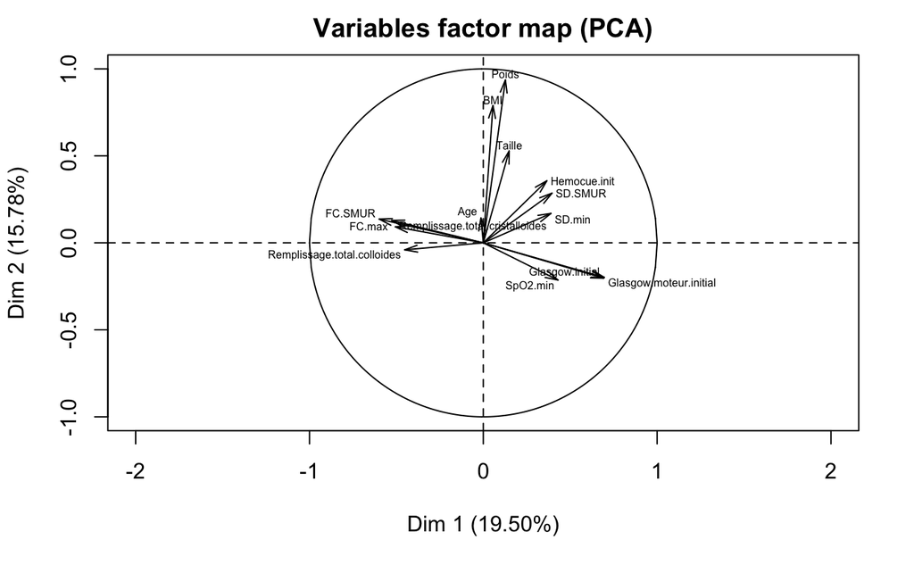

```r
plot(res.pca,choix='var',cex=0.5)
```

To perform our algorithm and evaluate its predictive perfermance, thus comparing to other existing methods, we consider the classical cross-validation procedures. We split the whole dataset into training and test sets, then estimate the parameters and select the variables on the training set, finally predict the response on the test set.

First we defines all the functions to use in SAEM and others methods.